# ISL Lab 2.3

```python
import numpy as np
import pandas as pd
import scipy
import scipy.stats
import matplotlib.pyplot as plt
import seaborn as sns
```

```python
import warnings
warnings.simplefilter('ignore',FutureWarning)
```

```python
np.arange(6)
```

```
array([0, 1, 2, 3, 4, 5])
```

```python
a = np.arange(6)
b = a.reshape((2,3))
b
```

```
array([[0, 1, 2],
       [3, 4, 5]])
```

```python
np.sqrt(b)
```

```
array([[0.        , 1.        , 1.41421356],
       [1.73205081, 2.        , 2.23606798]])
```

```python
rnorm = scipy.stats.norm(loc=0,scale=1)  # mean =  loc = 0, standard_deviation = scale = 1
x = rnorm.rvs(size=50)

err = scipy.stats.norm(loc=50, scale=0.1)
y = err.rvs(size=50)
```

```python
np.corrcoef(x,y)
```

```
array([[1.        , 0.09368519],
       [0.09368519, 1.        ]])
```

```python
np.random.seed(1303)
rnorm.rvs(size=8)
# Notice - same random numbers all of the time
```

```
array([-0.03425693,  0.06035959,  0.45511859, -0.36593175, -1.6773304 ,
        0.5910023 ,  0.41090101,  0.46972388])
```

```python
np.random.seed(3)
y = rnorm.rvs(size=100)
np.mean(y)
```

```
-0.10863707440606224
```

```python
np.var(y)
```

```
1.132081888283007
```

```python
np.sqrt(np.var(y))
```

```
1.0639933685333791
```

```python
np.std(y)
```

```
1.0639933685333791
```

## 2.3.2 Graphics

[figure not shown]

```python
x = rnorm.rvs(size=100)
y = rnorm.rvs(size=100)
ax = sns.scatterplot(x,y);
```

Have to dig back into MatPlotLib to set axis labels, so all is not perfect.

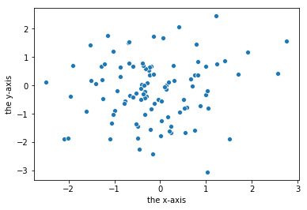

```python
ax = sns.scatterplot(x,y);
ax.set(xlabel="the x-axis",ylabel="the y-axis")
plt.show()
```

Adding a title is a little more annoying, per [Stack Overflow explanation of adding a title to a Seaborn plot](https://stackoverflow.com/questions/42406233/how-to-add-title-to-seaborn-boxplot). There are [more complex explanations](https://stackoverflow.com/questions/29813694/how-to-add-a-title-to-seaborn-facet-plot#29814281) that work with multiple subplots.

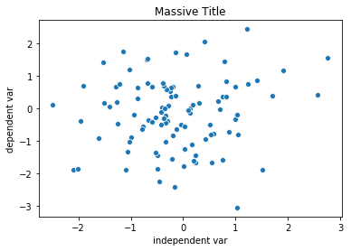

```python
ax = sns.scatterplot(x,y);
ax.set_xlabel('independent var')
ax.set_ylabel('dependent var')
ax.set_title('Massive Title')
plt.show();
```

[Saving an image to a file](https://stackoverflow.com/questions/9622163/save-plot-to-image-file-instead-of-displaying-it-using-matplotlib#9890599) is also pretty straightforward using savefig from PyPlot.

```python
ax = sns.scatterplot(x,y);
ax.set_title('Save this plot')
plt.savefig('unlabeled-axes.png');
# ugliness to avoid showing figure:
fig = plt.gcf()
plt.close(fig)
```

`np.linspace` makes equally spaced steps between the start and end

```python
x = np.linspace(-np.pi,np.pi,50)
```

A contour plot needs a 2D array of z values (x,y) -> f(x,y).

The hard part is getting the inputs to the function, or convincing f not to vectorize over x,y in parallel.

```python
x = np.linspace(-np.pi,np.pi,50)
y = x # for clarity only
xx,yy = np.meshgrid(x,y)
```

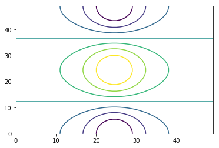

```python
def fbasic(x,y): return np.cos(y) / (1+x**2)
f = np.vectorize(lambda x,y: np.cos(y) / (1+x**2))
z = f(xx,yy)
plt.contour(z);
```

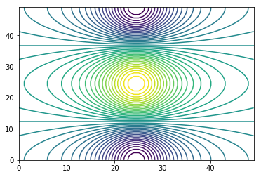

```python
plt.contour(z,45);
```

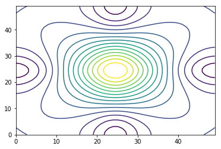

```python
def g1(x,y): return (fbasic(x,y)+fbasic(y,x))/2
g = np.vectorize(g1)
z2 = g(xx,yy)
plt.contour(z2,15);
```

`imshow` shows an image, like the `R` command `image`. Surely there is a way to get the coordinates input as well as the `z`, but in practice a regular grid seems most likely.

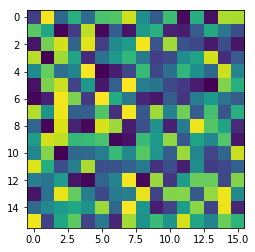

```python
randompix = np.random.random((16, 16))
plt.imshow(randompix);
```

## 3D Rendering

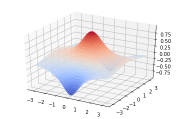

```python
from mpl_toolkits.mplot3d import Axes3D
from matplotlib import cm
from matplotlib.ticker import LinearLocator, FormatStrFormatter

fig = plt.figure()
ax = fig.add_subplot(111, projection='3d')

surf = ax.plot_surface(xx,yy,z, cmap=cm.coolwarm);
plt.show();
```

## 2.3.3 Indexing Data

```python
a = np.arange(1,17).reshape((4,4)).T   # matches R example
```

```python
print(a)
a[1,2]
```

```
[[ 1  5  9 13]
 [ 2  6 10 14]
 [ 3  7 11 15]
 [ 4  8 12 16]]
```

```
10
```

Beware if following code in the book. R indices start at 1, while Python indices start at 0.

```python
a[[0,2],[1,3]]
```

```
array([ 5, 15])
```

```python
a[[0,2],:]
```

[output not shown]

```python
a[:,[1,3]]
```

[output not shown]

If you combine the two in one set of brackets, they are traversed in parallel, getting you a[0,1] and a[2,3].

```python
a[[0,2],[1,3]]
```

[output not shown]

When you want a sub-array, index twice.

```python
a[[0,2],:][:,[1,3]]
```

[output not shown]

The `ix_` function makes grids out of indices that you give it. Clearer for this!

```python
a[np.ix_([0,2],[1,3])]
```

```
array([[ 5, 13],
       [ 7, 15]])
```

Note: R ranges include the last item, Python ranges do not.

```python
a[np.ix_(np.arange(0,3),np.arange(1,4))]
```

```
array([[ 5,  9, 13],
       [ 6, 10, 14],
       [ 7, 11, 15]])
```

```python
a[[0,1],]
```

```
array([[ 1,  5,  9, 13],
       [ 2,  6, 10, 14]])
```

```python
a[:,[0,1]]
```

```
array([[1, 5],
       [2, 6],
       [3, 7],
       [4, 8]])
```

```python
a[1,]
```

[output not shown]

Dropping columns is not as convenient in Python.

```python
b = np.delete(a,[0,2],0)
b
```

```
array([[ 2,  6, 10, 14],
       [ 4,  8, 12, 16]])
```

```python
c = np.delete(b,[0,2,3],1)
c
```

```
array([[6],
       [8]])
```

```python
a.shape
```

```
(4, 4)
```

## 2.3.4 Loading Data

**Note**: To get the data from a preloaded R dataset, I do `write_table(the_data, filename="whatever", sep="\t")` in R.

Cool fact: `read_table` can load straight from a URL.

```python
#auto = pd.read_table("Auto.data")
auto = pd.read_csv("http://www-bcf.usc.edu/~gareth/ISL/Auto.csv")
```

Get rid of any rows with missing data. This is *not* always a good idea.

```python
auto = auto.dropna()
```

```python
auto.shape
```

[output not shown]

```python
auto.columns
```

```
Index(['mpg', 'cylinders', 'displacement', 'horsepower', 'weight',
       'acceleration', 'year', 'origin', 'name'],
      dtype='object')
```

## 2.3.5 Graphical and Numerical Summaries

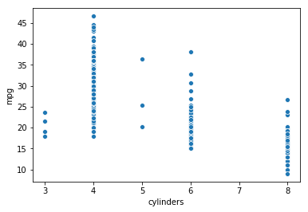

```python
sns.scatterplot(auto['cylinders'], auto['mpg']);
```

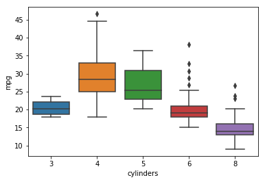

```python
sns.boxplot(x="cylinders", y="mpg", data=auto);
```

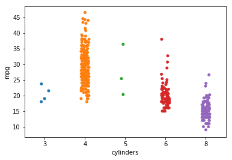

```python
sns.stripplot(x="cylinders", y="mpg", data=auto);
```

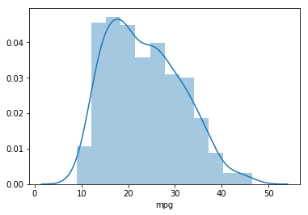

```python
sns.distplot(auto['mpg']);
```

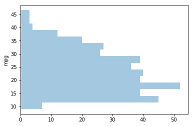

```python
sns.distplot(auto['mpg'],bins=15, kde=False, vertical=True);
```

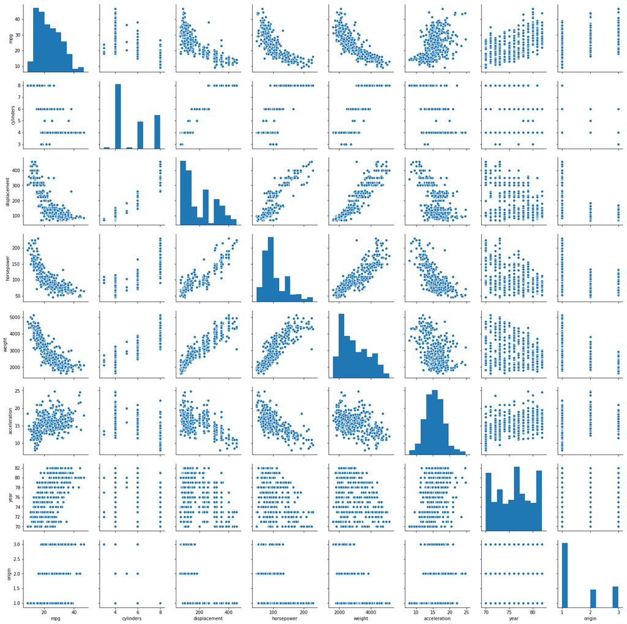

```python
sns.pairplot(data=auto);
```

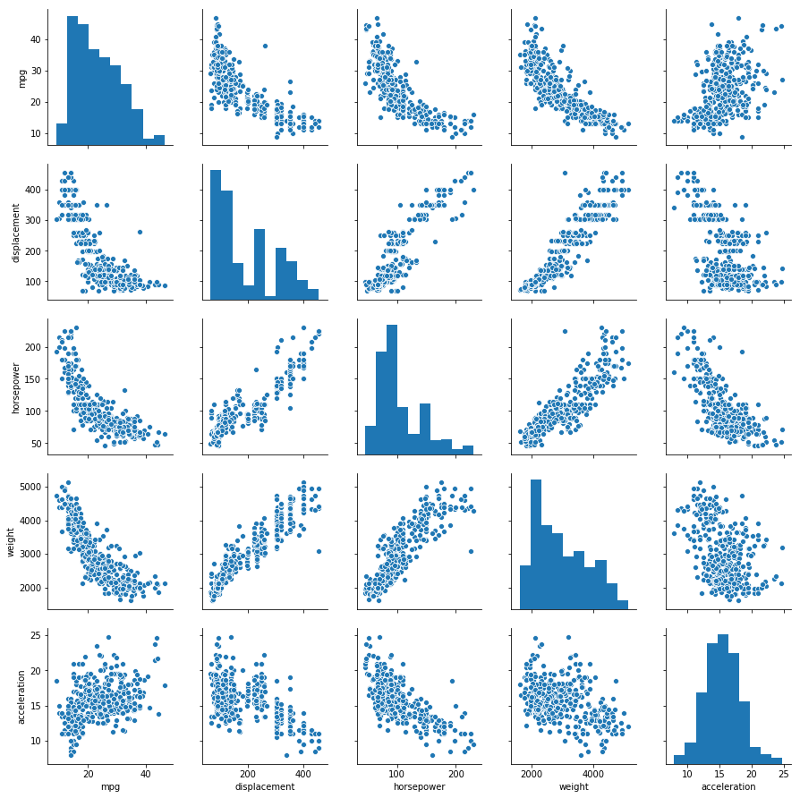

```python
sns.pairplot(data=auto[['mpg','displacement','horsepower',
                        'weight','acceleration']]);
```

I am not aware of a way to interactively identify points on a matplotlib plot that is similar to the R command `identify`.

```python
auto.describe()
```

|  | mpg | cylinders | displacement | horsepower | weight | acceleration | year | origin |
| --- | --- | --- | --- | --- | --- | --- | --- | --- |
| count | 392.000000 | 392.000000 | 392.000000 | 392.000000 | 392.000000 | 392.000000 | 392.000000 | 392.000000 |
| mean | 23.445918 | 5.471939 | 194.411990 | 104.469388 | 2977.584184 | 15.541327 | 75.979592 | 1.576531 |
| std | 7.805007 | 1.705783 | 104.644004 | 38.491160 | 849.402560 | 2.758864 | 3.683737 | 0.805518 |
| min | 9.000000 | 3.000000 | 68.000000 | 46.000000 | 1613.000000 | 8.000000 | 70.000000 | 1.000000 |
| 25% | 17.000000 | 4.000000 | 105.000000 | 75.000000 | 2225.250000 | 13.775000 | 73.000000 | 1.000000 |
| 50% | 22.750000 | 4.000000 | 151.000000 | 93.500000 | 2803.500000 | 15.500000 | 76.000000 | 1.000000 |
| 75% | 29.000000 | 8.000000 | 275.750000 | 126.000000 | 3614.750000 | 17.025000 | 79.000000 | 2.000000 |
| max | 46.600000 | 8.000000 | 455.000000 | 230.000000 | 5140.000000 | 24.800000 | 82.000000 | 3.000000 |

```python
auto['name'].value_counts().head()
```

```
ford pinto            5
amc matador           5
toyota corolla        5
toyota corona         4
chevrolet chevette    4
Name: name, dtype: int64
```

```python
auto['mpg'].describe()
```

```
count    392.000000
mean      23.445918
std        7.805007
min        9.000000
25%       17.000000
50%       22.750000
75%       29.000000
max       46.600000
Name: mpg, dtype: float64
```

## Miscellaneous Notes

Categorical data can be constructed using `astype('category')` in Pandas. Read [more about categorical data](https://pandas.pydata.org/pandas-docs/stable/categorical.html) if you need the information.

```python
auto['cylinders'] = auto['cylinders'].astype('category')
auto['cylinders'].describe()
```

```
count     392
unique      5
top         4
freq      199
Name: cylinders, dtype: int64
```

## Homework Starter

Easy access to [ISL datasets](http://www-bcf.usc.edu/~gareth/ISL/data.html) if you have internet access.

```python
college = pd.read_csv("http://www-bcf.usc.edu/~gareth/ISL/College.csv")
```